# Integrated Douyin and KuGou EDA

Music Platform Data Project

2026-11-19

# 1. Data Quality and Scope

Data quality is checked before any exploratory figure is produced. The integrated dataset covers 14 November 2024 to 13 November 2026. The daily panel contains 117530 song-date rows and 2568 title-coding rows. The observation layer contains 33123 platform records: 13774 Douyin records and 19349 KuGou records.

The integrated analysis keeps original platform records and uses title-based matching only as an exploratory cross-platform key. Missing native metrics mean that a song was not observed on that platform that day; they are not replaced with zero. Duplicate platform-date-track keys are checked before aggregation, and daily visibility is reduced to one song-date record using `any(observed == 1)`.

| platform | records | dates | tracks | missing_title | duplicate_track_date |
| --- | --- | --- | --- | --- | --- |
| douyin | 13774 | 729 | 95 | 0 | 7308 |
| kugou | 19349 | 730 | 95 | 0 | 10847 |

# 2. Platform-Specific and Shared Song Candidates

The first figure compares platform-only and shared song candidates. The shared segment is the same absolute count in both platform bars, while the platform-only segment shows the asymmetric size of each candidate set. The main conclusion is that the two platforms do not contribute equally many candidates and that the shared subset is much smaller than the platform-specific portions. Matching uses `cross_platform_song_id`, so the shared group represents title-based candidates rather than confirmed identical recordings.

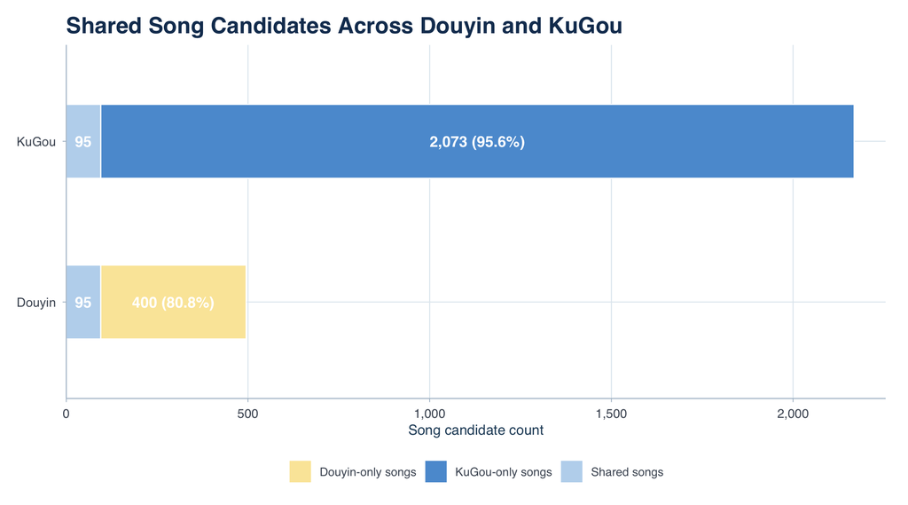

# 3. Monthly Observation Pattern

The monthly figure tracks three related quantities: distinct shared candidates observed on Douyin, distinct shared candidates observed on KuGou, and candidates observed on both platforms on the same day. The two platform curves describe monthly visibility, while `Both` is a stricter same-day overlap measure. The main conclusion is about changes in platform coverage and synchronization over time; `Both` should not be added across months or interpreted as the total number of daily records.

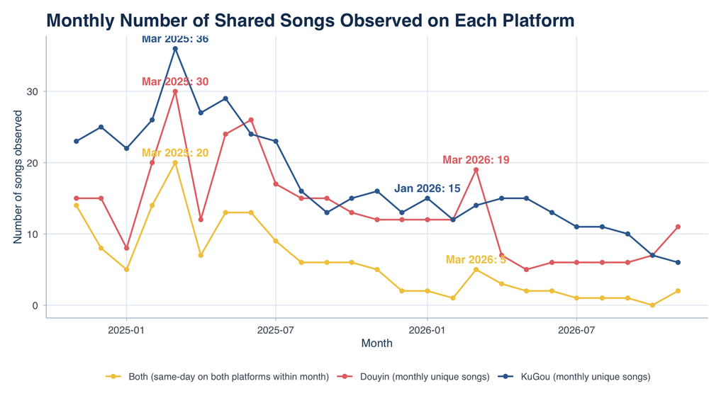

# 4. Temporal Overlap Distribution

The overlap histogram summarizes, for each shared candidate, the share of observation days that occurred on both platforms out of all days observed on either platform. Values near 0 indicate that the platforms usually captured the song on different days, whereas values near 1 indicate strong temporal coincidence. The distribution therefore distinguishes title overlap from synchronized visibility and provides the basis for the median overlap conclusion shown in the figure.

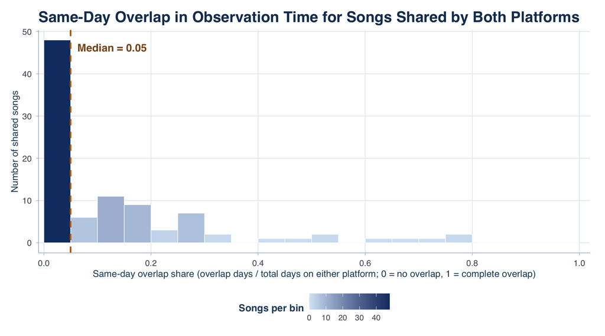

# 5. First-Observed Platform Timing

The first-observed figure compares the earliest archived date for each candidate on the two platforms. Bars to the left and right of zero show the direction and size of the timing gap, while the centre annotation counts candidates first observed on the same date. The distribution indicates whether one platform tends to appear earlier in the archived window, but this is an archive-order comparison rather than a release-order or causal claim.

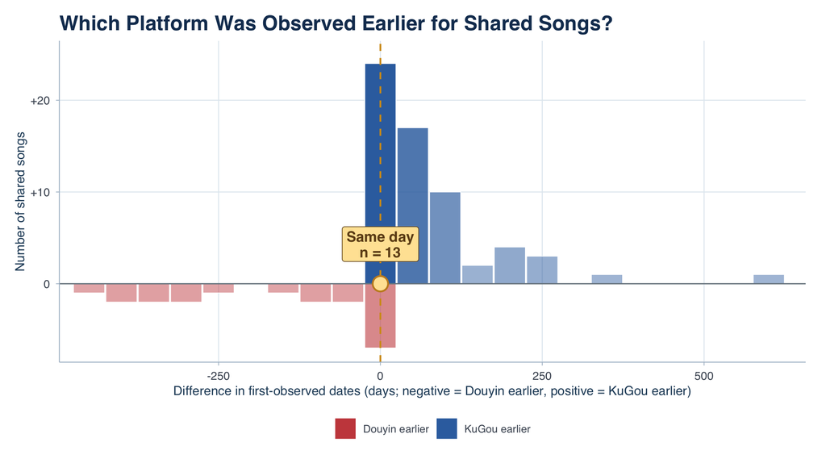

# 6. Shared Songs: Visibility and Rank Performance

Each point in this figure represents one shared title candidate. The two axes show the number of observed days on Douyin and KuGou, point size summarizes a top-heavy combined rank score, and colour shows the share of days with same-day presence on both platforms. Points near the diagonal have similar observation duration on the two platforms, while points far from it show platform-specific visibility differences. The figure is descriptive and gives repeated source rows equal treatment at the candidate level.

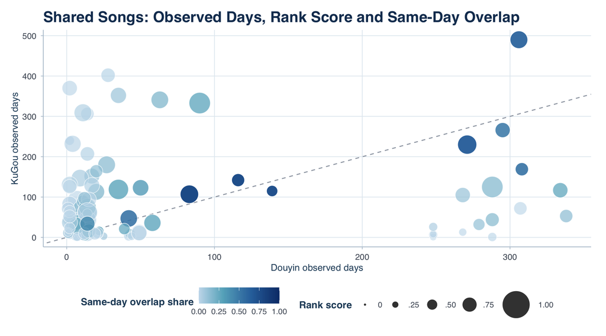

# 7. Genre and Mood: Platform Preference and First-Observed Timing

The genre and mood figures use the same two-part structure. The left panel compares the share of labelled candidates within Douyin and KuGou, while the right panel compares first-observed timing within each category. This allows composition and platform priority to be read separately: a category may be common on one platform without that platform consistently appearing earlier. Because labels can be multi-valued, all category shares are descriptive label shares rather than mutually exclusive song proportions.

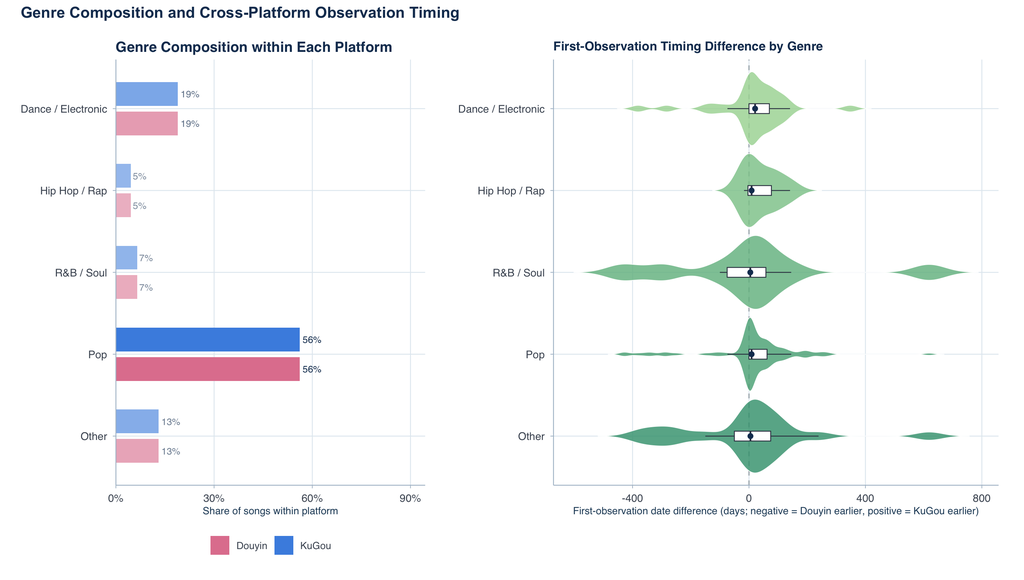

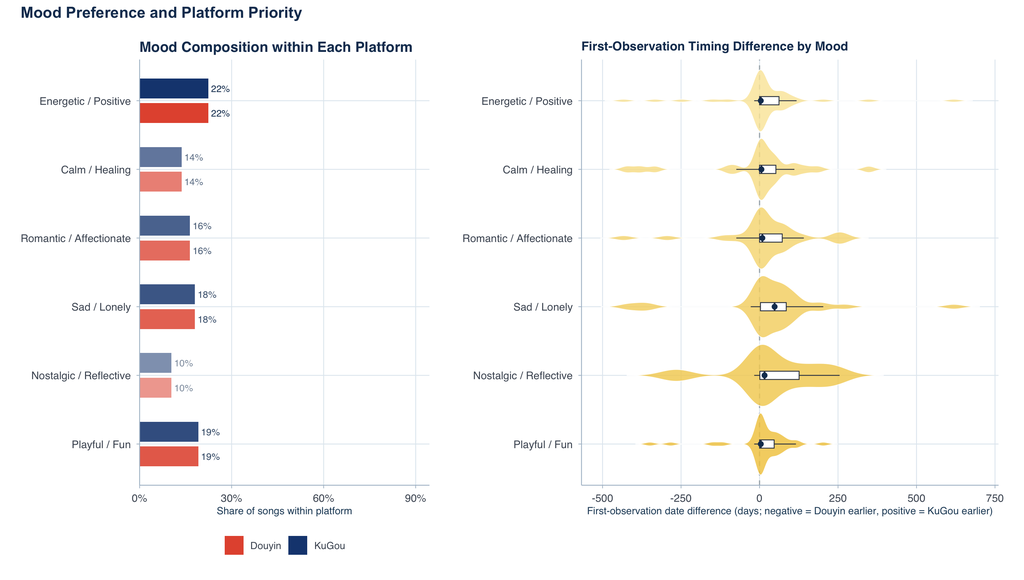

# 8. Main Findings and Limits

- The available candidate sets are highly asymmetric: KuGou contributes many more title candidates, while only a smaller subset is shared by title matching.
- Shared title candidates are not necessarily the same recording; version, artist and recording identity are not fully validated.
- Shared candidates show different observed-day patterns across platforms, and temporal overlap is generally limited.
- Mood comparisons are descriptive because labels may be multi-valued and platform taxonomies differ.
- Platform-native metrics remain separate. The EDA supports coverage, visibility, temporal overlap and composition analysis, but not a unified popularity score or causal conclusion.

The next step can use the shared candidate ID for exploratory interaction analysis with Douyin, while preserving `platform_record_id` and the original platform rows for version-level checks.

# 9. Reproducibility

This report reads the four processed tables in the separate `data_submission/data/processed/` package. The integrated observation layer is reconstructed from the daily panel, so no separate audit CSV is required. Render it from the EDA package with:

```r
rmarkdown::render("analysis/platform_combined_eda.Rmd")
```